# Unifying concepts: outline solutions to problems

Here we present outline solutions to the problems.

### 1. Existence of a phase transition in $d=2$.

Consider the simplest elementary excitation that will destroy long range order in the 2d system: a domain wall of $N$ segments which divides an Ising system of $L\times L$ spins into a spin up and a spin down part.

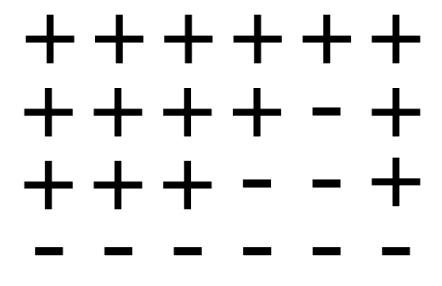

Figure 1: An $N$-step domain wall in an Ising lattice.

The associated energy cost is $2JN \equiv \Delta E$.

To evaluate the entropy gain due to a domain wall in the system we have to estimate $\Omega$ the number of possible paths for the domain wall. If we start at the left hand side then there are $L$ starting positions. At each step the domain wall can move to the right, move up or move down. This implies that the number of domain walls is approximately

$$\Omega\approx L3^N$$
Hence the entropy gain is:

$$\Delta S=Nk_B\ln 3+k_B\ln L\approx Nk_B\ln 3$$

Accordingly, the change in the free energy associated with inserting such a domain wall into an ordered system is

$$\Delta F=\Delta E-T\Delta S= N(2J-k_BT\ln 3)$$

For small enough $T <2J/(k_B\ln 3)$, the free energy change is positive. Thus the ordered phase is free energetically stable against formation of a wall. Accordingly there will be a non zero value for $T_c$ in two dimensions.

### 2. Correlation Length

Denote by $m$ the number of domain walls between sites $i$ and $j$. Then $s_is_j=1$ for $m$ even, and $s_is_j=-1$ for $m$ odd.

Hence

$$\langle s_i s_j\rangle =\sum_m p_m(-1)^m$$
with $p_m$ the probability of finding $m$ domain walls between them.

Now $p_m$ is given by the binomial distribution, with the probability of a single domain wall at each bond given by

$$p=\frac{e^{-2J/k_BT}}{1+e^{-2J/k_BT}}$$

and the probability of no wall is $1-p$. Now, in the regime where $T$ is small, $p$ is very small, and there will be few domain walls between sites $i$ and $j$. If additionally, $R_{ij}=|i-j|a$ is large, it tranpires that the binomial distribution assumes the limiting form of a Poissonian distribution (revise this if necessary). Thus

$$p_m=\frac{\bar{m}^me^{-\bar {m}}}{m!}$$

where $\bar{m}=p|j-i|=pR_{ij}/a$ . Then

$$\begin{align*}
\langle s_i s_j\rangle &=& e^{-\bar {m}}\sum_m\frac{(-1)^m\bar{m}^m} {m!}\approx e^{-2\bar{m}}\\
&=& e^{-2pR_{ij}/a}\\
&=& e^{-R_{ij}/\xi}
\end{align*}$$

with $\xi=a/2p$, the correlation length.

### 3. A model fluid

The van der Waals (vdW) equation of state (See Sec 4.4.1 of the book by Yeomans) is essentially a mean field theory for fluids. It relates the pressure and the volume of a fluid to the temperature:

$$\left(P+\frac{a}{V^2}\right)(V-b)=Nk_BT$$
where $a$ and $b$ are constants chosen to describe a specific substance and $N$ is Avogadro’s number. Hence

$$P=\frac{Nk_BT}{V-b}-\frac{a}{V^2}
\tag{1}$$

$$\Rightarrow \frac{\partial P}{\partial V}=\frac{-Nk_BT}{(V-b)^2}+\frac{2a}{V^3}$$

$$\Rightarrow \frac{\partial^2 P}{\partial V^2}=\frac{2Nk_BT}{(V-b)^3}-\frac{6a}{V^4}$$

Now at criticality (ie. a continuous transition).

$$\left(\frac{\partial P}{\partial V}\right)_T=\left(\frac{\partial^2 P}{\partial V^2}\right)_T=0$$

Thus
$$\begin{align*}
\frac{Nk_BT}{(V_c-b)^2} &=& \frac{2a}{V_c^3}\\
\frac{2Nk_BT}{(V_c-b)^3} &=& \frac{6a}{V_c^4}
\end{align*}$$

solving for $V_c$ and $Nk_BT_c$ yields

$$\begin{align*}
V_c &=& 3b\\
Nk_BT_c &=& \frac{8a}{27b}
\end{align*}$$

Substituting these two results into Equation 1 yields

$$P_c=\frac{a}{27b^2}$$

Now let $P=P_c p, V=V_cv, T=T_ct$ in the vdW eqn. (Note that in this context $t$ is not the reduced temperature).

$$\left(P_cp+\frac{a}{(V_cv)^2}\right)(V_cv-b)=N_Ak_BT_ct$$

Substituting in for $V_c, N_Ak_BT_c$ and $P_c$

$$\begin{align*}
\left(p\frac{a}{27b^2}+\frac{a}{9b^2v^2}\right)\left(3bv-b\right)&=&\frac{8a}{27b}t\\
\Rightarrow\left(p+\frac{3}{v^2}\right)\left(v-\frac{1}{3}\right)&=&\frac{8}{3}t
\end{align*}$$

This expression for the equation of state in terms of reduced variables is useful because reference to the system specific parameters $a$ and $b$ has vanished. In this form the equation is therefore universal.

Plotting $P/P_c$ vs $V/V_c$ for isotherms (values of $t$) and focussing on the region close to the critical point, one finds

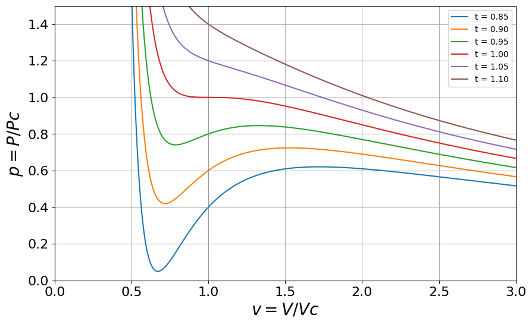

Figure 2: Isotherms of $p$ versus $v$ for various $t$ spanning the critical temperatures

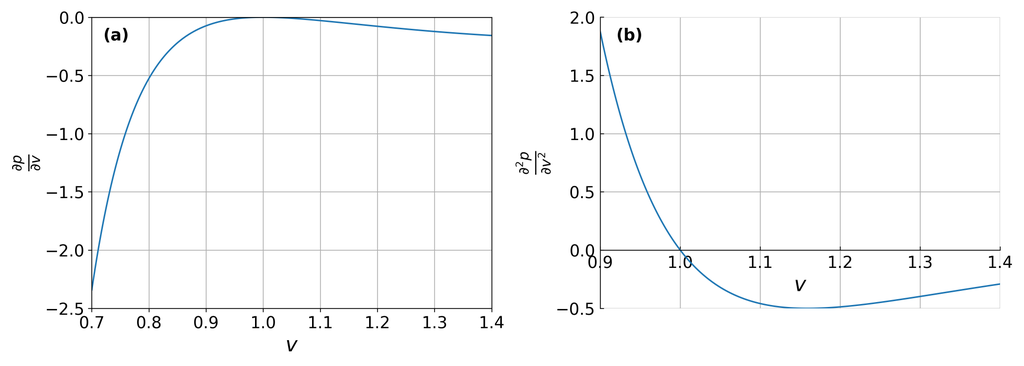

Figure 3: (a) $\frac{\partial p}{\partial v}$ for $T=T_c$. (b) $\frac{\partial^2 p}{\partial v^2}$ for $T=T_c$.

Plotting $(\frac{\partial p}{\partial v})_{t=1}$ and $(\frac{\partial^2 p}{\partial v^2})_{t=1}$, we see that there is indeed a point of inflexion on the critical isotherm, at $v=1$, this is the critical point (ie. a continuous phase transition), Figure 3 .

Subcritical isotherms (first order phase transition) exhibit a so called van-der Waals loop.

To find the compressibility critical exponent $\gamma$, we recall that

$$\kappa_T=\frac{-1}{V}\left(\frac{\partial V}{\partial P}\right)_T=\frac{-1}{p_cv}\left(\frac{\partial v}{\partial p}\right)_t\propto \tilde{t}^{-\gamma}$$
with $\tilde{t}=(T-T_c)/T_c$ small.

Now from the reduced equation of state

$$\frac{\partial p}{\partial v}=\frac{-8t}{3(v-1/3)^2}+\frac{6}{v^3}$$
setting $t=\tilde{t}+1$ and $v=1$ gives $\frac{\partial p}{\partial v} =-6\tilde{t}$, ie the compressibility diverges

$$\kappa_T\propto \tilde{t}^{-1}$$
ie. $\gamma=1$, which is the same as the mean field result which we derived in another context of the magnetic susceptibility.

### 4. Mean field theory of the Ising model heat capacity

We insert into the expression for the mean Ising energy

$$\langle E \rangle =-J\sum_{<i,j>}\langle s_is_j\rangle\:,$$
the simplest mean field approximation $\langle s_is_j\rangle=\langle s_i\rangle\langle s_j\rangle=m^2$. Recalling the behaviour of the order parameter for small $t$, that the number of bonds $=qN/2$, and the mean field value of $T_c=qJ/k_B$, we have for $T<T_c$

$$\begin{align*}
\langle E \rangle &=& \frac{-NqJm^2}{2}\\
\: &=& \frac{3NqJt}{2}\\
\: &=& \frac{3Nk_B(T-T_c)}{2}
\end{align*}$$
while $\langle E \rangle= \textrm{ constant}$ for $T>T_c$.

Hence differentiating, we find
$$\begin{align*}
C_H&=& 0 &~~~~~T>T_c\\
C_H&=& 3Nk_B/2 & ~~~~~T\le T_c
\end{align*}$$

This independence of the heat capacity on $t$ corresponds to a critical exponent $\alpha=0$

### 5. Magnetisation and fluctuations

The free energy is

$$F=-k_BT\ln Z$$
with the partition function

$$Z=\sum_{{s}}\exp[-({\cal H}-hM)/k_BT]$$

Thus
$$\begin{align*}
-\left(\frac{\partial F}{\partial h}\right)_T &=& k_BT\frac{1}{Z}\left(\frac{\partial Z}{\partial h}\right)_T\\
\: &=&\frac{1}{Z}\sum_{{s}}M \exp[-({\cal H}-hM)/k_BT]\\
&=& \langle M\rangle
\end{align*}$$
where we have used the definition of the average of an observable given in lectures.

Now

$$\begin{align*}
\left(\frac{\partial^2 F}{\partial h^2}\right)_T &=& -k_BT\left[\frac{1}{Z}\left(\frac{\partial^2 Z}{\partial h^2}\right)_T-\left(\frac{\partial Z}{\partial h}\right)_T\frac{1}{Z^2}\left(\frac{\partial Z}{\partial h}\right)_T\right]\\
\: &=&\frac{-1}{k_BT}\left[\frac{1}{Z}\sum_{{s}}M^2 \exp[-({\cal H}-hM)/k_BT]-\langle M\rangle^2\right]\\
\: &=& \frac{-1}{k_BT}\left[\langle M^2\rangle-\langle M\rangle^2\right]
\end{align*}$$

You should recognise the terms in square brackets as the variance of the magnetisation distribution.

Thus the susceptibility is
$$\chi_H\equiv\frac{\partial \langle M\rangle}{\partial h}=\frac{1}{k_BT}\left[\langle M^2\rangle-\langle M\rangle^2\right]$$

Incidently, this is known as the fluctuation-dissipation theorem. It is a neat result, because it allows you to calculate the response to a perturbation from equilibrium, without actually perturbing the system! Instead one merely looks at the form of the equilibrium fluctuations. It is used extensively in computer simulations.

### 6. Spin-1 Ising model

As in lectures, the mean field Hamiltonian for a single spin is

$${\cal H}(s_0)=-s_0\left(qJm + H\right)$$
The probability of finding this spin with value $s_0$ is
$$\begin{align*}
p(s_0) &=& \frac{e^{-\beta{\cal H}(s_0)}} {\sum_{s_0=0,\pm 1}e^{-\beta{\cal H}(s_0)}}\\
&=&\frac{e^{\beta s_0(qJm+H)}}{1+e^{\beta(qJm+H)}+e^{-\beta(qJm+H)}}
\end{align*}$$

Now for consistency $\langle s_0\rangle=m$, so
$$\begin{align*}
m &=& \sum_{s_0=0,\pm 1}s_0p(s_0)\\
\:&=& \frac{0+e^{\beta(qJm+H)}-e^{\beta(qJm+H)}} {e^0+e^{\beta(qJm+H)}+e^{-\beta(qJm+H)}}\\
\:&=& \frac{2\sinh[\beta(Jqm+h)]}{1+2\cosh[\beta(Jqm+h)]}
\end{align*}$$
To get the critical temperature, we can solve this graphically. One plots the RHS as a function of $m$, for various $\beta$. On the same graph one plots the curve $y=m$ (representing the LHS). $T_c$ is the highest $T$ for which the two curves intersect.

### 7. Transfer Matrix

The transfer matrix is a list of the possible interactions of a pair of spins with one another and with a magnetic field. For a 1d spin-1/2 system it takes the form:
$${\bf V}(H)=\begin{bmatrix}
e^{\beta(J+H)} & e^{-\beta J} \\
e^{-\beta J} & e^{\beta(J-H)}
\end{bmatrix}$$
We need to find the eigenvalues, so we solve the characteristic equation det(${\bf V}-\lambda {\bf I})=0$, i.e.

$${\bf V}(H)=\begin{vmatrix}
e^{\beta(J+H)} -\lambda & e^{-\beta J} \\
e^{-\beta J} & e^{\beta(J-H)}-\lambda
\end{vmatrix} =0$$

Then $\lambda^2-(a+d)\lambda+(ad-bc)=0$. So

$$\begin{align*}
\lambda_\pm &=& \frac{a+d\pm\sqrt{(a+d)^2-4(ad-bc)}}{2}\\
\lambda_{\pm} &=& e^{\beta J}\cosh(\beta H) \pm \frac{1}{2}\sqrt{e^{2\beta J}4\cosh^2\beta H-4(e^{2\beta J}-e^{-2\beta J})}\\
\lambda_{\pm} &=& e^{\beta J}\cosh(\beta H) \pm \sqrt{e^{2\beta J}\sinh^2\beta H+e^{-2\beta J}}.
\end{align*}$$

(You’ll need the identity $\cosh^2 x-\sinh^2 x = 1$).

From lectures, you should know that the partition function

$$\begin{align}
Z=\textrm{Tr}({\bf V}^N)=&\lambda_+^N+\lambda_-^N\\
\approx & \lambda_+^N \hspace{5mm}\textrm{N~large}
\end{align}$$

where $\lambda_+$ is the largest of the two evals.

Hence the free energy $F=-k_BT\ln(Z)$ can be written

$$F=-Nk_BT\ln \left[e^{\beta J}\cosh(\beta H) + \sqrt{e^{2\beta J}\sinh^2\beta H+e^{-2\beta J}}\right].$$

Now the magnetisation per site is

$$m=-\frac{1}{N}\frac{\partial F}{\partial H}=\frac{k_BT}{\lambda_+}\frac{\partial \lambda_+}{\partial H}$$

You can either be a hero here, or use a symbolic solution program like Maple or Wolfram Alpha. I did the latter to find the stated result.

$$m=\frac{\sinh \beta H}{\sqrt{\sinh^2\beta H+\exp{(-4\beta J)}}}$$

Hence at zero $H$, there is no spontaneous magnetisation at any $T$.

### 8. Landau theory

If this were an Ising model problem (ie a microscopic model) we could write down the partition function, get an explicit expression for the free energy and differentiate once (wrt $T$) to get the energy and again (wrt $T$) to get the heat capacity. But the starting point for Landau theory is the free energy itself, so we need another starting point, namely thermodynamics. The appropriate thermodynamic potential for the magnet is $F=U-TS-MH$ with $U$ the internal energy. Then $$
$$\begin{align*}
dF &=& dU-TdS-SdT-MdH-HdM\\
\: &=& TdS+HdM-TdS-SdT-MdH-HdM\\
\: &=& -SdT-MdH
\end{align*}$$
where we have used the first law for a magnet $dU=TdS+HdM$, Thus

$$\begin{align*}
\left(\frac{\partial F}{\partial T}\right)_H &=& -S\\
-T\left(\frac{\partial^2 F}{\partial T^2}\right)_H &=&T\frac{dS}{dT}=\frac{dQ}{dT}\\ C_H=-T\left(\frac{\partial^2 F}{\partial T^2}\right)_H
\end{align*}$$

where $C_H$ is the specific heat at constant field and we have used the fact that $dS=dQ/T$.

Now from lectures, the equilibrium magnetisation in the Landau free energy is given by

$$m^2=\frac{-a_2}{2a_4}$$
for $T<T_c$ and zero otherwise. Substituting this into the Landau free energy $F=F_0+a_2m^2+a_4m^4$ gives

$$\begin{align*}
F = F_0 & \quad T>T_c\\
F = -a_2^2/4a_4 & \quad T < T_c
\end{align*}$$

Using the fact that $a_2=\tilde{a_2} t$, with $t=(T-T_c)/T_c$ and differentiating wrt $T$ twice, to get the heat capacity, we find

$$\begin{align*}
C_H &=& 0 & \quad T\to T_c^+\\
C_H &=& \frac{T\tilde a_2^2}{2a_4T_c^2} & \quad T \to T_c^-\:,
\end{align*}$$
The jump discontinuity rather that a divergence in the specific heat at $T=T_c$ formally corresponds to a critical exponent $\alpha=0$.

To get the susceptibility exponent, we add a magnetic field to the free energy

$$F(m)=F_0+a_2m^2+a_4m^4-Hm$$

Then the equilibrium magnetisation satisfies

$$\begin{align*}
\frac{dF}{dm}&=&2\tilde{a_2} tm+4a_4m^3-H=0\\
\Rightarrow H&=&2\tilde{a_2} tm+4a_4m^3\\
\Rightarrow \left(\frac{\partial H}{\partial m}\right )_T&=&2\tilde{a_2} t+12a_4m^2
\end{align*}$$
Now using the results that $m^2=0$ for $t>0$ and $m^2=-\tilde{a_2}t/(2a_4)$ for $t<0$, we have that in both cases

$$\left(\frac{\partial H}{\partial m}\right )_T\propto t$$

Hence

$$\left(\frac{\partial m}{\partial H}\right )_T\propto t^{-1}$$
so $\gamma=1$.

### 9. Scaling equation of state

The equilibrium state corresponds to the minimum of the free energy $\partial F/\partial M=0$. This gives the equation of state

$$H=2\tilde{a_2}tm+4a_4m^3$$
(Note that we ignore the solution $H=m=0$ which corresponds to a maximum of the free energy.)

The near critical power law scaling of the magnetisation is $m\propto t^\beta$ and $m\propto H^{1/\delta}$. To find a scaling form for the equation of state we need to transform to scaled variables $H/m^\delta$ and $t/m^{1/\beta}$. We can get a scaling equation in terms of these variables by dividing through the equation of state by $m^3$, so that

$$\frac{H}{m^{3}}=g\left(\frac{2\tilde{a_2}t}{m^2}\right)+4a_4$$

Hence $\delta=3$ and $\beta=1/2$.

The choice of scale $a_4=1/4$ and $\tilde{a_2}=1/2$ yields the given form of the scaling function.

### 10. Scaling laws

First of all recall the definition of the critical exponents:
$$\begin{align*}
m & \propto & t^{\beta};&~~~~~(h=0) \\
\chi_T & \propto & t^{-\gamma};&~~~~~(h=0) \\
C_H & \propto & t^{-\alpha};&~~~~~(h=0) \\
m & \propto & h^{1/\delta}.&~~~~~(t=0) \\
\end{align*}$$

The free energy in generalised homogeneous form is

$$F(\lambda^a t,\lambda^b h)=\lambda F(t,h)$$

The first of the scaling relations to be derived was covered in lectures: Let $\lambda^a=1/t$, so that $\lambda=t^{-1/a}$. Then

$$\begin{align*}
F(t,h)&=&t^{1/a}F(1,t^{-b/a}h)\\
m(t,h)&=&-\left(\frac{\partial F}{\partial h}\right)_t= -t^{(1-b)/a} \left.\frac{\partial F(1,y)}{\partial y}\right|_{ht^{-b/a}}=t^{(1-b)/a}m(1,ht^{-b/a})
\end{align*}$$

so when $h=0$, we have $m(1,t^{-b/a}h)=m(1,0)=\textrm{ const}$ and hence we can identify $\boxed{\beta=(1-b)/a}$.

We also have for the isothermal susceptibility

$$\chi=\left(\frac{\partial m}{\partial h}\right)_t=-t^{(1-2b)/a}\left.\frac{\partial^2 F(1,y)}{\partial y^2}\right|_{ht^{-b/a}},$$
so taking again $h=0$, we find $\boxed{\gamma=(2b-1)/a}$.

$$\begin{align*}
C_H &=& -\frac{T}{T_c^2}\frac{\partial^2}{\partial t^2}[t^{1/a}F(1,t^{-b/a}h)]\\
C_H &\approx& -\frac{1}{T_c}\frac{\partial^2}{\partial t^2}[t^{1/a}F(1,t^{-b/a}h)]\\
C_H &=& -\frac{1}{T_c}\frac{1}{a}(\frac{1}{a}-1)t^{(1/a-2)}F(1,0)
\end{align*}$$
Here we have neglected all derivatives of $F$ since they are multiplied by at least one power of $h$ which is zero. Hence $\boxed{\alpha=2-1/a}$.

Finally, if we let $\lambda^b=1/h$, so that $\lambda=h^{-1/b}$ and consider the critical isotherm $t=0$. Then

$$\begin{align*}
F(t,h)&=&h^{1/b}F(h^{-a/b}t,1)\\
\Rightarrow m(t,h)&=& \frac{ta}{b}h^{(1-a-b)/b}\left.\frac{\partial F(x,1)}{\partial x}\right|_{h^{-a/b}t}-\frac{1}{b}h^{1/b-1}F(h^{-a/b}t,1).
\end{align*}$$
so when $t=0$, we get $m(0,h)$ and can identify $\boxed{\delta=b/(1-b)}$.

To derive the relationships (``scaling laws’’) among the critical exponents, we eliminate $a$ and $b$ from the boxed scaling relations. Setting $a=(2-\alpha)^{-1}$ in the first scaling relation, we find $b=1-\beta/(2-\alpha)$. Substituting this into the second scaling relation gives the second of the two scaling laws quoted in the notes. Substituting into the 4th scaling relation gives the first scaling law.

### 11. Classical nucleation theory

**(a)** To find the critical radius $r^*$, we differentiate $\Delta G(r)$ with respect to $r$ and set the derivative equal to zero:

$$\frac{d\Delta G}{dr} = 4\pi r^2 \Delta G_v + 8\pi r \gamma = 0$$

This gives

$$r^* = -\frac{2\gamma}{\Delta G_v}$$

Since $\Delta G_v < 0$, $r^*$ is positive, as expected.

**(b)** To obtain the critical barrier height:

Substitute $r^*$ into the expression for $\Delta G(r)$:

$$\Delta G^* = \frac{4}{3} \pi \left(-\frac{8\gamma^3}{\Delta G_v^3}\right) \Delta G_v + 4\pi \left(\frac{4\gamma^2}{\Delta G_v^2}\right) \gamma$$

which simplifies to

$$\Delta G^* = -\frac{32\pi \gamma^3}{3 \Delta G_v^2} + \frac{16\pi \gamma^3}{\Delta G_v^2} = \frac{16\pi \gamma^3}{3 \Delta G_v^2}$$

**(c)** The free energy change per unit volume is approximately proportional to the undercooling:

$$\Delta G_v \propto \Delta T$$

From part (b), the nucleation barrier is:

$$\Delta G^* \propto \frac{\gamma^3}{(\Delta G_v)^2} \propto \frac{1}{\Delta T^2}$$

Thus, as $\Delta T$ increases, $\Delta G^*$ decreases rapidly. A smaller energy barrier means nucleation becomes more probable. Therefore, the nucleation rate increases sharply with undercooling.

Note, however, that at very high undercooling, atomic mobility may decrease due to low temperature, which can limit nucleation despite the small barrier.

### 12. Colloidal diffusion

We start from the given formal solution of the Langevin equation for the velocity:

$$u(t) = u_0 e^{-\gamma t} + \frac{e^{-\gamma t}}{M} \int_{0}^{t} e^{\gamma t'} F(t') \, dt'.$$

with a goal to compute the mean square velocity $\langle u^2(t)\rangle$.

Let
$$A = u_0 e^{-\gamma t},
\qquad
B = \frac{e^{-\gamma t}}{M} \int_{0}^{t} e^{\gamma t'} F(t') \, dt'.$$
Then
$$\langle u^2(t)\rangle = \langle (A + B)^2 \rangle
= \langle A^2 \rangle + 2\langle A B \rangle + \langle B^2 \rangle.$$

1. $\langle A^2 \rangle = u_0^2 e^{-2\gamma t}.$
2. $\langle A B \rangle = u_0 \frac{e^{-\gamma t}}{M} \, e^{-\gamma t} \int_0^t e^{\gamma t'} \langle F(t')\rangle \, dt' = 0$  
   (since we assume $\langle F(t)\rangle = 0$).
3. For the noise term, assume
   $$\langle F(t)F(t')\rangle = q \,\delta(t - t').$$
   Then
   $$\langle B^2 \rangle
   = \frac{e^{-2\gamma t}}{M^2} \int_{0}^{t}\int_{0}^{t}
   e^{\gamma t'} e^{\gamma t''} \langle F(t')F(t'')\rangle \, dt' dt''
   = \frac{e^{-2\gamma t}}{M^2}\,q \int_{0}^{t} e^{2\gamma t'} \, dt'
   = \frac{q}{2\gamma M^2} \bigl(1 - e^{-2\gamma t}\bigr).$$

Putting these together yields
$$\boxed{
\langle u^2(t)\rangle
= u_0^2 e^{-2\gamma t}
\;+\;
\frac{q}{2\gamma M^2}\,\bigl(1 - e^{-2\gamma t}\bigr).
}$$

Now relate the noise strength $q$ to temperature

At long times $t\to\infty$ the particle reaches thermal equilibrium, so by equipartition
$$\tfrac12 M \langle u^2 \rangle_{\infty}
= \tfrac12 kT
\;\Longrightarrow\;
\langle u^2 \rangle_{\infty}
= \frac{kT}{M}
= \frac{q}{2\gamma M^2}
\;\Longrightarrow\;
q = 2\gamma\,M kT.$$

Substituting back gives the full time‐dependent result:

$$\boxed{
\langle u^2(t)\rangle
= \frac{kT}{M}
\;+\;\Bigl(u_0^2 - \frac{kT}{M}\Bigr)\,e^{-2\gamma t}.
}$$

## 13. Einstein’s expression for the diffusion coefficient

We have

$$X(t) - X(0) = \int_0^t u(t') dt'$$

and substituting this into the definition of $D$, we find:

$$D = \lim_{t \to \infty} \frac{1}{2t} \int_0^t dt_1 \int_0^t dt_2 \langle u(t_1) u(t_2) \rangle$$

Note: the use of different dummy variables $t_2$ and $t_2$ allows us to write the square as a product. Now change variables $t_2 = t_1 + \tau$:

$$D = \lim_{t \to \infty} \frac{1}{t} \int_0^t dt_1 \int_0^{t - t_1} d\tau \langle u(t_1) u(t_1 + \tau) \rangle$$

In thermal equilibrium the process is stationary, so the two‐time correlation depends only on the time‐difference:

$$\langle u(t_1) u(t_1 + \tau) \rangle = \langle u(t_0) u(t_0 + \tau) \rangle$$
for any arbitrary $t_0$.

Doing the integral with respect to $t_1$ we find:

$$D = \int_0^\infty \langle u(t_0) u(t_0 + t) \rangle dt,$$

where we renamed $\tau \to t$ and assume that $\langle u u \rangle$ will fall off so fast that the upper limit doesn’t matter.

### 14. Life in one dimension

In the interval between $t$ and $t + \delta t$,

$$p_{n-1}(t) \alpha \delta t : \quad n - 1 \rightarrow n;$$

$$p_{n+1}(t) \beta \delta t : \quad n + 1 \rightarrow n.$$

These are both gains. There is also a loss $p_n(t)(\alpha + \beta)\delta t$ which is the probability of the particle hopping from $n$ to one of the neighbouring sites.

The master equation follows as:

$$\dot{p}_n(t) = \alpha p_{n-1}(t) + \beta p_{n+1}(t) - (\alpha + \beta) p_n(t).$$

Introduce the generating function $F(z,t)$, thus:

$$F(z,t) = \sum_{n=-\infty}^\infty p_n(t) z^n,$$

where initial and boundary conditions imply $F(1,t) = 1$ and $F(z,0) = 1$.

Multiply the master equation through by $z^n$ and sum over $n$ to obtain the equation for $F$:

$$\frac{\partial F}{\partial t} = [\alpha z + \beta z^{-1} - (\alpha + \beta)] F$$

with easy solution:

$$F(z,t) = e^{-(\alpha + \beta)t} e^{\alpha z t} e^{\beta z^{-1} t} F(z,0)$$

where the initial condition gives us $F(z,0) = 1$.

We obtain the $p_n(t)$ by expanding the exponentials in (respectively) powers of $z$ and $z^{-1}$; thus:

$$F(z,t) = e^{-(\alpha + \beta)t} \sum_{k=0}^\infty \sum_{l=0}^\infty \frac{\alpha^k \beta^l t^{k+l}}{k!l!} z^{k - l}.$$

The probability $p_n$ is the coefficient of $z^n$. Consider two cases:

**Case 1** $n \ge 0$, set $k = n + l$.

$$p_n(t) = e^{-(\alpha + \beta)t} (\alpha t)^n \sum_{l=0}^\infty \frac{(\alpha \beta t^2)^l}{l!(l+n)!}$$

**Case 2** $n \le 0$, set $l = k - n$.

$$p_n(t) = e^{-(\alpha + \beta)t} (\beta t)^{-n} \sum_{k=0}^\infty \frac{(\alpha \beta t^2)^k}{k!(k - n)!}$$

Find the mean and rms deviation by direct use of the generating function.

$$\langle n \rangle = \sum_{n=-\infty}^{\infty} n p_n(t) = \left. \frac{\partial F}{\partial z} \right|_{z=1} = (\alpha - \beta)t$$

$$\langle n^2 \rangle = \sum_{n=-\infty}^{\infty} n^2 p_n(t) = \left. \left( \frac{\partial}{\partial z} \left( z \frac{\partial F}{\partial z} \right) \right) \right|_{z=1} = (\alpha + \beta)t + (\alpha - \beta)^2 t^2$$

### 15. Master equation

The rates of change of $n_+$ and $n_-$ are clearly given by the master equations:

$$\frac{dn_+}{dt} = -n_+ v_{+-} + n_- v_{-+};$$

$$\frac{dn_-}{dt} = n_+ v_{+-} - n_- v_{-+}.$$

At equilibrium the right-hand sides of the above master equations must vanish. Hence the ratio of the transition probabilities is given by:

$$\left. \frac{v_{-+}}{v_{+-}} = \frac{n_+}{n_-} \right|_{\text{eq}} = e^{-2\beta \varepsilon}.$$

with $\beta = 1/k\tau$, as usual.

Subtracting one of the above master equations from the other, we obtain:

$$\frac{dn}{dt} = 2n_+ v_{+-} - 2n_- v_{-+}$$

Then, noting that $N = n_- + n_+$ and $n = n_- - n_+$ implies that:

$$n_- = \frac{N + n}{2} \quad \text{and} \quad n_+ = \frac{N - n}{2},$$

we have:

$$\frac{dn}{dt} = -n(v_{+-} + v_{-+}) + N(v_{+-} - v_{-+})$$

which can be written in the suggestive form:

$$\frac{dn}{dt} = -\frac{1}{\tau} \left[ n(t) + \frac{N(v_{+-} - v_{-+})}{v_{+-} + v_{-+}} \right]$$

where

$$\tau = \frac{1}{v_{+-} + v_{-+}}.$$

This can further be written as

$$\frac{dn}{dt} = -\frac{1}{\tau} \left[ n(t) - n_{\text{eq}} \right],$$

where the equilibrium value of $n(t)$ is:

$$n_{\text{eq}} = N \frac{v_{+-} - v_{-+}}{v_{+-} + v_{-+}} = N \tanh(\beta \varepsilon).$$

The solution is:

$$n(t) = n_{\text{eq}} + e^{-t/\tau} [n(0) - n_{\text{eq}}].$$

You should note the behaviour of this solution as $t \to 0$ and $t \to \infty$.

### 16. Detailed balance

**(a)** For individual states, the rates of transition are:

$$1 \rightarrow 2 \quad = \quad v_{12} p_1$$

$$2 \rightarrow 1 \quad = \quad v_{21} p_2$$

Define groups of states:  
Group A: $\alpha = 1, \cdots, N$  
Group B: $\beta = 1, \cdots, M$

Then

$$\sum_{\alpha=1}^N p_\alpha = p_A \quad ; \quad \sum_{\beta=1}^M p_\beta = p_B$$

(Note: $p_A \ne p_B$)

**Overall rate**

$$A \rightarrow B = \sum_{\alpha=1}^N \sum_{\beta=1}^m v_{\alpha \beta} p_\alpha$$

**Overall rate**

$$B \rightarrow A = \sum_{\alpha=1}^N \sum_{\beta=1}^m v_{\beta \alpha} p_\beta$$

where  
$v_{\alpha \beta} = v_{\beta \alpha}$ : jump rate symmetry  
$p_\alpha = p_\beta$ : principle of equal *a priori* probabilities (for microstates)

Hence:

$$\text{rate}(A \rightarrow B) \equiv v_{AB} p_A^{eq}$$

$$\text{rate}(B \rightarrow A) \equiv v_{BA} p_B^{eq}$$

are equal in equilibrium.

$$p_A = \frac{e^{-\beta F_A}}{Z},$$

for the canonical ensemble, and a similar result may be written for group $B$.

As this system is in the canonical ensemble, we can assume that it is in a large heat bath, with the ‘system + heat bath’ being treated as ‘isolated’.

Take $A$ to be the microstate $i$ of the system + any state of the heat bath, such that

$$E_{system} + E_{reservoir} = E \, \text{(fixed)}.$$

For a large reservoir,

$$p_i = \frac{e^{-\beta E_i}}{z} = \textrm{``$p_A$''},$$

with a similar result for $B$.

Hence the result of part (a), that

$$\text{Rate}(A \rightarrow B) = \text{Rate}(B \rightarrow A)$$

means here that

$$v_{ij} p_i = v_{ji} p_j,$$

even though, for states of different system energy $E_i$,

$$p_i \ne p_j \quad \text{and} \quad v_{ij} \ne v_{ji}.$$

This implies:

$$\frac{v_{ij}}{v_{ji}} = \frac{p_j}{p_i} = e^{\beta(E_j - E_i)}$$

This result has important implications for Monte Carlo simulation

### 17. Jump processes

**(a)** Label by $p_i(t)$ the probability to be in state $i$ at time $t$. From the question:

- From state 1 one can only jump to 2 with rate $\lambda_0$.
- From state 2 one can jump to 1 or to 3, each with rate $\lambda_0$.
- From state 3 one can only jump to 2 with rate $\lambda_0$.

Hence the gain–loss equations are
$$\begin{aligned}
\dot p_1 &= -\lambda_0\,p_1 + \lambda_0\,p_2,\\
\dot p_2 &= \lambda_0\,p_1 - 2\lambda_0\,p_2 + \lambda_0\,p_3,\\
\dot p_3 &= \lambda_0\,p_2 - \lambda_0\,p_3.
\end{aligned}$$

Writing $\mathbf p=(p_1,p_2,p_3)^{\!T}$, one checks immediately that
$$\dot{\mathbf p}
\;=\;
\lambda_0
\begin{pmatrix}
-1 & 1 & 0\\
1 & -2 & 1\\
0 & 1 & -1
\end{pmatrix}
\mathbf p
\;=\;M\,\mathbf p,$$
as claimed. Note that the columns of $M$ sum to zero, ensuring $\sum_i\dot p_i=0$ (probability conservation).

**(b)** An equilibrium state $\mathbf p^\textrm{ eq}$ satisfies
$$M\,\mathbf p^\textrm{ eq}=0,
\quad
\sum_{i=1}^3 p^\textrm{ eq}_i=1.$$
From the first row of $M\,\mathbf p=0$ we get
$$-\,p^\textrm{ eq}_1 + p^\textrm{ eq}_2 =0
\;\Longrightarrow\;
p^\textrm{ eq}_1 = p^\textrm{ eq}_2.$$
From the third row,
$$p^\textrm{ eq}_2 - p^\textrm{ eq}_3=0
\;\Longrightarrow\;
p^\textrm{ eq}_2 = p^\textrm{ eq}_3.$$
Hence all three components are equal. Normalizing,
$$p^\textrm{ eq}_1 = p^\textrm{ eq}_2 = p^\textrm{ eq}_3 = \tfrac13,$$
i.e.
$$\mathbf p^\textrm{ eq} = \bigl(\tfrac13,\tfrac13,\tfrac13\bigr).$$

**(c)** The matrix
$$M = \lambda_0
\begin{pmatrix}
-1 & 1 & 0\\
1 & -2 & 1\\
0 & 1 & -1
\end{pmatrix}$$
is (up to $\lambda_0$) the negative of the graph-Laplace operator of the path $1\!-\!2\!-\!3$. Its characteristic polynomial is
$$\det(M -\mu I)
=-\mu(\mu+\lambda_0)(\mu+3\lambda_0),$$
so the eigenvalues are
$$\mu_1=0,\quad \mu_2=-\lambda_0,\quad \mu_3=-3\lambda_0.$$
Since the zero‐eigenvalue has multiplicity one, the null space of $M$ is one-dimensional. Imposing $\sum_i p_i=1$ picks out a unique vector in that null space. Hence the equilibrium $(\tfrac13,\tfrac13,\tfrac13)$ is the only steady-state probability vector.